# PCA GMD_Reshaping Data

Hunsi Jayaprakash

2/24/2022

```r
library(tidyverse)
library(factoextra)
```

## Read data

```r
file_name <- ("https://raw.githubusercontent.com/jyurko/cs_1950_brain_proj/main/KLU_APC2_Master_2021_07_07.csv?token=GHSAT0AAAAAABQQ7BMDVZWJ7F7SRYQVFIG4YRZE2LQ")
df <- readr::read_csv(file_name,col_names = TRUE)
```

Other markdowns perform basic counts and checks and so those will not be repeated here.

## Extract GMD regional data

```r
gmd_regional_df <- df %>% select(Vault_Scan_ID, Vault_UID, MR_Scan_Date, starts_with("GMD_"))
```

```r
gmd_regional_wf <- gmd_regional_df %>%
  select(starts_with("Vault"), MR_Scan_Date, starts_with("GMD_regional"))
```

Organize the data into long-format to better understand the region and side groups.

```r
my_separate <- function(the_data, num_us)
{
  names_keep <- the_data %>% select(-name) %>% names()

  the_data %>%
    tidyr::separate(name,
                    c("result_type", "regional_word",
                      sprintf("name_%02d", 1:(num_us-1))),
                    sep = "_") %>%
    rename(!!!c("side_name" = sprintf("name_%02d", num_us-1))) %>%
    tidyr::unite("region_name",
                 sprintf("name_%02d", 1:(num_us-2)),
                 sep = "_") %>%
    select(all_of(c(names_keep,
                    "result_type", "region_name", "side_name")))
}
```

```r
gmd_regional_lf <- gmd_regional_wf %>%
  tibble::rowid_to_column() %>%
  pivot_longer(cols = starts_with("GMD_regional")) %>%
  mutate(num_underscores = stringr::str_count(name, pattern = "_")) %>%
  group_by(num_underscores) %>%
  tidyr::nest() %>%
  mutate(ready_data = purrr::map2(data, num_underscores, my_separate)) %>%
  select(num_underscores, ready_data) %>%
  tidyr::unnest(ready_data) %>%
  ungroup()
```

Check the long-format.

```r
gmd_regional_lf %>% glimpse()
```

```
## Rows: 9,932
## Columns: 9
## $ num_underscores <int> 3, 3, 3, 3, 3, 3, 3, 3, 3, 3, 3, 3, 3, 3, 3, 3, 3, 3, ~
## $ rowid           <int> 1, 1, 1, 1, 1, 1, 1, 1, 1, 1, 1, 1, 1, 1, 1, 1, 1, 1, ~
## $ Vault_Scan_ID   <dbl> 800569, 800569, 800569, 800569, 800569, 800569, 800569~
## $ Vault_UID       <dbl> 900534, 900534, 900534, 900534, 900534, 900534, 900534~
## $ MR_Scan_Date    <dttm> 2010-06-25, 2010-06-25, 2010-06-25, 2010-06-25, 2010-~
## $ value           <dbl> 0.0237345550, 0.0105957400, 0.0000039000, 0.0000000274~
## $ result_type     <chr> "GMD", "GMD", "GMD", "GMD", "GMD", "GMD", "GMD", "GMD"~
## $ region_name     <chr> "Caudate", "Caudate", "Fusiform", "Fusiform", "Heschl"~
## $ side_name       <chr> "L", "R", "L", "R", "L", "R", "L", "R", "L", "R", "L",~
```

## Group and average

Start by averaging the values per person across scans.

```r
gmd_person_summary <- gmd_regional_lf %>%
  group_by(result_type, Vault_UID, region_name, side_name) %>%
  summarise(num_rows = n(),
            num_scans = n_distinct(Vault_Scan_ID),
            num_dates = n_distinct(MR_Scan_Date),
            num_missing = sum(is.na(value)),
            avg_value = mean(value, na.rm = TRUE),
            min_value = min(value, na.rm = TRUE),
            max_value = max(value, na.rm = TRUE),
            .groups = 'drop')
```

[output not shown]

[output cut: 1192 more lines]

[output not shown]

[output not shown]

[output cut: 1192 more lines]

[output not shown]

```r
gmd_person_summary %>% glimpse()
```

```
## Rows: 4,836
## Columns: 11
## $ result_type <chr> "GMD", "GMD", "GMD", "GMD", "GMD", "GMD", "GMD", "GMD", "G~
## $ Vault_UID   <dbl> 900534, 900534, 900534, 900534, 900534, 900534, 900534, 90~
## $ region_name <chr> "Caudate", "Caudate", "Frontal_Inf_Oper", "Frontal_Inf_Ope~
## $ side_name   <chr> "L", "R", "L", "R", "L", "R", "L", "R", "L", "R", "L", "R"~
## $ num_rows    <int> 3, 3, 3, 3, 3, 3, 3, 3, 3, 3, 3, 3, 3, 3, 3, 3, 3, 3, 3, 3~
## $ num_scans   <int> 2, 2, 2, 2, 2, 2, 2, 2, 2, 2, 2, 2, 2, 2, 2, 2, 2, 2, 2, 2~
## $ num_dates   <int> 2, 2, 2, 2, 2, 2, 2, 2, 2, 2, 2, 2, 2, 2, 2, 2, 2, 2, 2, 2~
## $ num_missing <int> 2, 2, 2, 2, 2, 2, 2, 2, 2, 2, 2, 2, 2, 2, 2, 2, 2, 2, 2, 2~
## $ avg_value   <dbl> 0.0237345550, 0.0105957400, 0.0315095370, 0.0481284370, 0.~
## $ min_value   <dbl> 0.0237345550, 0.0105957400, 0.0315095370, 0.0481284370, 0.~
## $ max_value   <dbl> 0.0237345550, 0.0105957400, 0.0315095370, 0.0481284370, 0.~
```

## Reshape to wide-format

Check the number of regions and sides.

```r
gmd_person_summary %>% count(region_name, side_name)
```

```
## # A tibble: 52 x 3
##    region_name       side_name     n
##    <chr>             <chr>     <int>
##  1 Caudate           L            93
##  2 Caudate           R            93
##  3 Frontal_Inf_Oper  L            93
##  4 Frontal_Inf_Oper  R            93
##  5 Frontal_Inf_Orb_2 L            93
##  6 Frontal_Inf_Orb_2 R            93
##  7 Frontal_Inf_Tri   L            93
##  8 Frontal_Inf_Tri   R            93
##  9 Frontal_Med_Orb   L            93
## 10 Frontal_Med_Orb   R            93
## # ... with 42 more rows
```

Reshape the AVERAGE values to wide-format.

```r
gmd_avg_person_wf <- gmd_person_summary %>%
  select(Vault_UID, avg_value, result_type, region_name, side_name) %>%
  tidyr::unite(result_region_name,
               c("result_type", "region_name", "side_name"),
               sep = "-") %>%
  pivot_wider(id_cols = "Vault_UID", names_from = "result_region_name", values_from = "avg_value")
```

Check missings.

```r
gmd_avg_person_wf %>%
  purrr::map_dbl(~sum(is.na(.)))
```

```
##                Vault_UID            GMD-Caudate-L            GMD-Caudate-R
##                        0                        8                        8
##   GMD-Frontal_Inf_Oper-L   GMD-Frontal_Inf_Oper-R  GMD-Frontal_Inf_Orb_2-L
##                        8                        8                        8
##  GMD-Frontal_Inf_Orb_2-R    GMD-Frontal_Inf_Tri-L    GMD-Frontal_Inf_Tri-R
##                        8                        8                        8
##    GMD-Frontal_Med_Orb-L    GMD-Frontal_Med_Orb-R      GMD-Frontal_Mid_2-L
##                        8                        8                        8
##      GMD-Frontal_Mid_2-R      GMD-Frontal_Sup_2-L      GMD-Frontal_Sup_2-R
##                        8                        8                        8
## GMD-Frontal_Sup_Medial-L GMD-Frontal_Sup_Medial-R           GMD-Fusiform-L
##                        8                        8                        8
##           GMD-Fusiform-R             GMD-Heschl-L             GMD-Heschl-R
##                        8                        8                        8
##             GMD-Insula-L             GMD-Insula-R             GMD-OFCant-L
##                        8                        8                        8
##             GMD-OFCant-R           GMD-Pallidum-L           GMD-Pallidum-R
##                        8                        8                        8
##    GMD-ParaHippocampal-L    GMD-ParaHippocampal-R       GMD-Parietal_Inf-L
##                        8                        8                        8
##       GMD-Parietal_Inf-R        GMD-Postcentral-L        GMD-Postcentral-R
##                        8                        8                        8
##         GMD-Precentral-L         GMD-Precentral-R            GMD-Putamen-L
##                        8                        8                        8
##            GMD-Putamen-R             GMD-Rectus-L             GMD-Rectus-R
##                        8                        8                        8
##      GMD-Rolandic_Oper-L      GMD-Rolandic_Oper-R      GMD-SupraMarginal-L
##                        8                        8                        8
##      GMD-SupraMarginal-R       GMD-Temporal_Inf-L       GMD-Temporal_Inf-R
##                        8                        8                        8
##       GMD-Temporal_Mid-L       GMD-Temporal_Mid-R  GMD-Temporal_Pole_Mid-L
##                        8                        8                        8
##  GMD-Temporal_Pole_Mid-R  GMD-Temporal_Pole_Sup-L  GMD-Temporal_Pole_Sup-R
##                        8                        8                        8
##       GMD-Temporal_Sup-L       GMD-Temporal_Sup-R
##                        8                        8
```

Rows before dropping the missings.

```r
gmd_avg_person_wf %>% nrow()
```

```
## [1] 93
```

Rows for complete cases.

```r
gmd_avg_person_wf %>%
  drop_na() %>%
  nrow()
```

```
## [1] 85
```

## Correlation

Show the correlation plot for the complete cases.

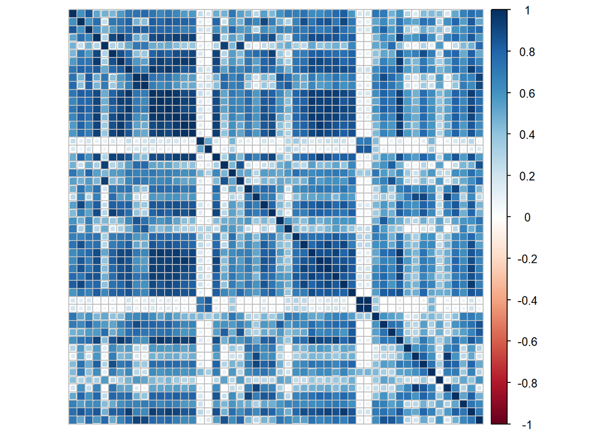

```r
gmd_avg_person_wf %>%
  select(-Vault_UID) %>%
  drop_na() %>%
  as.data.frame() %>%
  cor() %>%
  corrplot::corrplot(method = 'square', tl.pos = 'n')
```

Reorder by a hierarchical cluster.

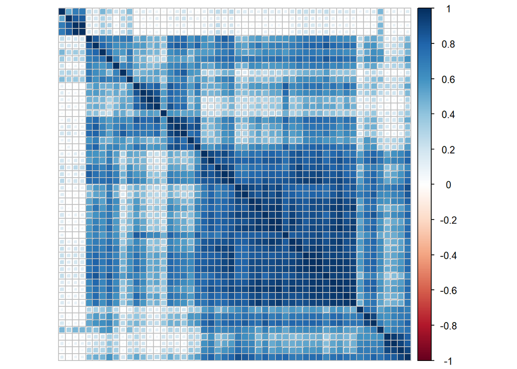

```r
gmd_avg_person_wf %>%
  select(-Vault_UID) %>%
  drop_na() %>%
  as.data.frame() %>%
  cor() %>%
  corrplot::corrplot(method = 'square', tl.pos = 'n',
                     order = 'hclust', hclust.method = 'ward.D2')
```

```r
gmd_avg_person_wf %>% select(-Vault_UID) %>% ncol()
```

```
## [1] 52
```

## PCA

Apply PCA to the complete cases but do NOT include the person ID. The person ID is just an identifier that will help with the visualizations and interpretation.

```r
ready_wf <- gmd_avg_person_wf %>%
  select(-Vault_UID) %>%
  drop_na()
ready_wf %>% dim()
```

```
## [1] 85 52
```

```r
ready_wf %>% glimpse()
```

```
## Rows: 85
## Columns: 52
## $ `GMD-Caudate-L`            <dbl> 0.02373456, 0.02026311, 0.03167635, 0.02712~
## $ `GMD-Caudate-R`            <dbl> 0.01059574, 0.01234981, 0.02083026, 0.01220~
## $ `GMD-Frontal_Inf_Oper-L`   <dbl> 0.03150954, 0.02720781, 0.04106963, 0.03345~
## $ `GMD-Frontal_Inf_Oper-R`   <dbl> 0.04812844, 0.04475419, 0.06693525, 0.05195~
## $ `GMD-Frontal_Inf_Orb_2-L`  <dbl> 0.03049385, 0.01626174, 0.03930057, 0.01530~
## $ `GMD-Frontal_Inf_Orb_2-R`  <dbl> 0.05045992, 0.04390187, 0.06409519, 0.05274~
## $ `GMD-Frontal_Inf_Tri-L`    <dbl> 0.01842660, 0.01554526, 0.02542379, 0.01893~
## $ `GMD-Frontal_Inf_Tri-R`    <dbl> 0.01736503, 0.01546353, 0.02623209, 0.02020~
## $ `GMD-Frontal_Med_Orb-L`    <dbl> 0.02545738, 0.01786042, 0.03116225, 0.01842~
## $ `GMD-Frontal_Med_Orb-R`    <dbl> 0.02621201, 0.01604705, 0.03120604, 0.01941~
## $ `GMD-Frontal_Mid_2-L`      <dbl> 0.03616134, 0.03341164, 0.05480564, 0.04011~
## $ `GMD-Frontal_Mid_2-R`      <dbl> 0.03598107, 0.03170708, 0.05211487, 0.03661~
## $ `GMD-Frontal_Sup_2-L`      <dbl> 0.03108797, 0.03021054, 0.04783442, 0.03448~
```

[output cut: 39 more lines]

Perform PCA

```r
ready_pca <- prcomp(ready_wf, center = TRUE, scale. = TRUE)
```

```r
ready_pca  %>% glimpse()
```

```
## List of 5
##  $ sdev    : num [1:52] 5.62 2.41 1.97 1.43 1.27 ...
##  $ rotation: num [1:52, 1:52] 0.1317 0.1497 0.1446 0.16 0.0945 ...
##   ..- attr(*, "dimnames")=List of 2
##   .. ..$ : chr [1:52] "GMD-Caudate-L" "GMD-Caudate-R" "GMD-Frontal_Inf_Oper-L" "GMD-Frontal_Inf_Oper-R" ...
##   .. ..$ : chr [1:52] "PC1" "PC2" "PC3" "PC4" ...
##  $ center  : Named num [1:52] 0.0286 0.014 0.036 0.0559 0.0279 ...
##   ..- attr(*, "names")= chr [1:52] "GMD-Caudate-L" "GMD-Caudate-R" "GMD-Frontal_Inf_Oper-L" "GMD-Frontal_Inf_Oper-R" ...
##  $ scale   : Named num [1:52] 0.00421 0.00256 0.00463 0.00821 0.00683 ...
##   ..- attr(*, "names")= chr [1:52] "GMD-Caudate-L" "GMD-Caudate-R" "GMD-Frontal_Inf_Oper-L" "GMD-Frontal_Inf_Oper-R" ...
##  $ x       : num [1:85, 1:52] -5.56 -9.91 10.69 -4.17 3.5 ...
##   ..- attr(*, "dimnames")=List of 2
##   .. ..$ : NULL
##   .. ..$ : chr [1:52] "PC1" "PC2" "PC3" "PC4" ...
##  - attr(*, "class")= chr "prcomp"
```

```r
### the center and scales are the means and sd's of the variables
ready_pca$center
```

```
##            GMD-Caudate-L            GMD-Caudate-R   GMD-Frontal_Inf_Oper-L
##             2.858663e-02             1.404747e-02             3.596903e-02
##   GMD-Frontal_Inf_Oper-R  GMD-Frontal_Inf_Orb_2-L  GMD-Frontal_Inf_Orb_2-R
##             5.590036e-02             2.788387e-02             5.378260e-02
##    GMD-Frontal_Inf_Tri-L    GMD-Frontal_Inf_Tri-R    GMD-Frontal_Med_Orb-L
##             2.067542e-02             2.190547e-02             2.530678e-02
##    GMD-Frontal_Med_Orb-R      GMD-Frontal_Mid_2-L      GMD-Frontal_Mid_2-R
##             2.566036e-02             4.378546e-02             4.098718e-02
##      GMD-Frontal_Sup_2-L      GMD-Frontal_Sup_2-R GMD-Frontal_Sup_Medial-L
##             3.818176e-02             4.122525e-02             3.192815e-02
## GMD-Frontal_Sup_Medial-R           GMD-Fusiform-L           GMD-Fusiform-R
##             3.584042e-02             4.564795e-06             3.001093e-08
##             GMD-Heschl-L             GMD-Heschl-R             GMD-Insula-L
##             3.558245e-02             3.967308e-02             7.990696e-03
##             GMD-Insula-R             GMD-OFCant-L             GMD-OFCant-R
##             6.200296e-03             3.510301e-03             4.611479e-03
##           GMD-Pallidum-L           GMD-Pallidum-R    GMD-ParaHippocampal-L
##             1.804361e-02             1.335405e-02             4.866508e-03
##    GMD-ParaHippocampal-R       GMD-Parietal_Inf-L       GMD-Parietal_Inf-R
##             3.025610e-03             2.066715e-02             3.948292e-02
##        GMD-Postcentral-L        GMD-Postcentral-R         GMD-Precentral-L
##             3.650170e-02             2.813756e-02             3.628171e-02
##         GMD-Precentral-R            GMD-Putamen-L            GMD-Putamen-R
##             5.672399e-02             2.996720e-02             2.870759e-02
##             GMD-Rectus-L             GMD-Rectus-R      GMD-Rolandic_Oper-L
##             3.353244e-05             3.548849e-05             1.471399e-02
##      GMD-Rolandic_Oper-R      GMD-SupraMarginal-L      GMD-SupraMarginal-R
##             1.574908e-02             3.545207e-02             2.464997e-02
##       GMD-Temporal_Inf-L       GMD-Temporal_Inf-R       GMD-Temporal_Mid-L
##             9.680359e-05             2.302373e-05             2.543911e-03
##       GMD-Temporal_Mid-R  GMD-Temporal_Pole_Mid-L  GMD-Temporal_Pole_Mid-R
##             1.276878e-03             1.955479e-06             2.127784e-04
##  GMD-Temporal_Pole_Sup-L  GMD-Temporal_Pole_Sup-R       GMD-Temporal_Sup-L
##             9.179676e-04             1.259041e-02             2.984597e-02
##       GMD-Temporal_Sup-R
##             3.621922e-02
```

```r
ready_wf %>% purrr::map_dbl(~mean(.))
```

```
##            GMD-Caudate-L            GMD-Caudate-R   GMD-Frontal_Inf_Oper-L
##             2.858663e-02             1.404747e-02             3.596903e-02
##   GMD-Frontal_Inf_Oper-R  GMD-Frontal_Inf_Orb_2-L  GMD-Frontal_Inf_Orb_2-R
##             5.590036e-02             2.788387e-02             5.378260e-02
##    GMD-Frontal_Inf_Tri-L    GMD-Frontal_Inf_Tri-R    GMD-Frontal_Med_Orb-L
##             2.067542e-02             2.190547e-02             2.530678e-02
##    GMD-Frontal_Med_Orb-R      GMD-Frontal_Mid_2-L      GMD-Frontal_Mid_2-R
##             2.566036e-02             4.378546e-02             4.098718e-02
##      GMD-Frontal_Sup_2-L      GMD-Frontal_Sup_2-R GMD-Frontal_Sup_Medial-L
##             3.818176e-02             4.122525e-02             3.192815e-02
## GMD-Frontal_Sup_Medial-R           GMD-Fusiform-L           GMD-Fusiform-R
##             3.584042e-02             4.564795e-06             3.001093e-08
##             GMD-Heschl-L             GMD-Heschl-R             GMD-Insula-L
##             3.558245e-02             3.967308e-02             7.990696e-03
##             GMD-Insula-R             GMD-OFCant-L             GMD-OFCant-R
##             6.200296e-03             3.510301e-03             4.611479e-03
##           GMD-Pallidum-L           GMD-Pallidum-R    GMD-ParaHippocampal-L
##             1.804361e-02             1.335405e-02             4.866508e-03
##    GMD-ParaHippocampal-R       GMD-Parietal_Inf-L       GMD-Parietal_Inf-R
##             3.025610e-03             2.066715e-02             3.948292e-02
##        GMD-Postcentral-L        GMD-Postcentral-R         GMD-Precentral-L
##             3.650170e-02             2.813756e-02             3.628171e-02
##         GMD-Precentral-R            GMD-Putamen-L            GMD-Putamen-R
##             5.672399e-02             2.996720e-02             2.870759e-02
##             GMD-Rectus-L             GMD-Rectus-R      GMD-Rolandic_Oper-L
##             3.353244e-05             3.548849e-05             1.471399e-02
##      GMD-Rolandic_Oper-R      GMD-SupraMarginal-L      GMD-SupraMarginal-R
##             1.574908e-02             3.545207e-02             2.464997e-02
##       GMD-Temporal_Inf-L       GMD-Temporal_Inf-R       GMD-Temporal_Mid-L
##             9.680359e-05             2.302373e-05             2.543911e-03
##       GMD-Temporal_Mid-R  GMD-Temporal_Pole_Mid-L  GMD-Temporal_Pole_Mid-R
##             1.276878e-03             1.955479e-06             2.127784e-04
##  GMD-Temporal_Pole_Sup-L  GMD-Temporal_Pole_Sup-R       GMD-Temporal_Sup-L
##             9.179676e-04             1.259041e-02             2.984597e-02
##       GMD-Temporal_Sup-R
##             3.621922e-02
```

```r
ready_pca$scale
```

```
##            GMD-Caudate-L            GMD-Caudate-R   GMD-Frontal_Inf_Oper-L
##             4.212997e-03             2.562908e-03             4.631339e-03
##   GMD-Frontal_Inf_Oper-R  GMD-Frontal_Inf_Orb_2-L  GMD-Frontal_Inf_Orb_2-R
##             8.209906e-03             6.834140e-03             9.492176e-03
##    GMD-Frontal_Inf_Tri-L    GMD-Frontal_Inf_Tri-R    GMD-Frontal_Med_Orb-L
##             3.239546e-03             2.992868e-03             3.858540e-03
##    GMD-Frontal_Med_Orb-R      GMD-Frontal_Mid_2-L      GMD-Frontal_Mid_2-R
##             4.020331e-03             5.835824e-03             5.537218e-03
##      GMD-Frontal_Sup_2-L      GMD-Frontal_Sup_2-R GMD-Frontal_Sup_Medial-L
##             5.031772e-03             5.676645e-03             5.137574e-03
## GMD-Frontal_Sup_Medial-R           GMD-Fusiform-L           GMD-Fusiform-R
##             5.525110e-03             3.776504e-06             3.360215e-08
##             GMD-Heschl-L             GMD-Heschl-R             GMD-Insula-L
##             6.387548e-03             8.312539e-03             1.521668e-03
##             GMD-Insula-R             GMD-OFCant-L             GMD-OFCant-R
##             1.242685e-03             1.047255e-03             1.516036e-03
##           GMD-Pallidum-L           GMD-Pallidum-R    GMD-ParaHippocampal-L
##             3.113417e-03             2.348139e-03             1.038721e-03
##    GMD-ParaHippocampal-R       GMD-Parietal_Inf-L       GMD-Parietal_Inf-R
##             8.668299e-04             2.668587e-03             5.782610e-03
##        GMD-Postcentral-L        GMD-Postcentral-R         GMD-Precentral-L
##             4.659150e-03             4.487399e-03             4.879905e-03
##         GMD-Precentral-R            GMD-Putamen-L            GMD-Putamen-R
##             6.816844e-03             4.402734e-03             3.766293e-03
##             GMD-Rectus-L             GMD-Rectus-R      GMD-Rolandic_Oper-L
##             3.274249e-05             3.420965e-05             2.814454e-03
##      GMD-Rolandic_Oper-R      GMD-SupraMarginal-L      GMD-SupraMarginal-R
##             2.123168e-03             5.726319e-03             3.763771e-03
##       GMD-Temporal_Inf-L       GMD-Temporal_Inf-R       GMD-Temporal_Mid-L
##             4.034310e-05             9.405510e-06             5.239098e-04
##       GMD-Temporal_Mid-R  GMD-Temporal_Pole_Mid-L  GMD-Temporal_Pole_Mid-R
##             4.501353e-04             9.338787e-07             8.123802e-05
##  GMD-Temporal_Pole_Sup-L  GMD-Temporal_Pole_Sup-R       GMD-Temporal_Sup-L
##             2.395234e-04             3.024658e-03             4.449023e-03
##       GMD-Temporal_Sup-R
##             4.921962e-03
```

```r
ready_wf %>% purrr::map_dbl(~sd(.))
```

```
##            GMD-Caudate-L            GMD-Caudate-R   GMD-Frontal_Inf_Oper-L
##             4.212997e-03             2.562908e-03             4.631339e-03
##   GMD-Frontal_Inf_Oper-R  GMD-Frontal_Inf_Orb_2-L  GMD-Frontal_Inf_Orb_2-R
##             8.209906e-03             6.834140e-03             9.492176e-03
##    GMD-Frontal_Inf_Tri-L    GMD-Frontal_Inf_Tri-R    GMD-Frontal_Med_Orb-L
##             3.239546e-03             2.992868e-03             3.858540e-03
##    GMD-Frontal_Med_Orb-R      GMD-Frontal_Mid_2-L      GMD-Frontal_Mid_2-R
##             4.020331e-03             5.835824e-03             5.537218e-03
##      GMD-Frontal_Sup_2-L      GMD-Frontal_Sup_2-R GMD-Frontal_Sup_Medial-L
##             5.031772e-03             5.676645e-03             5.137574e-03
## GMD-Frontal_Sup_Medial-R           GMD-Fusiform-L           GMD-Fusiform-R
##             5.525110e-03             3.776504e-06             3.360215e-08
##             GMD-Heschl-L             GMD-Heschl-R             GMD-Insula-L
##             6.387548e-03             8.312539e-03             1.521668e-03
##             GMD-Insula-R             GMD-OFCant-L             GMD-OFCant-R
##             1.242685e-03             1.047255e-03             1.516036e-03
##           GMD-Pallidum-L           GMD-Pallidum-R    GMD-ParaHippocampal-L
##             3.113417e-03             2.348139e-03             1.038721e-03
##    GMD-ParaHippocampal-R       GMD-Parietal_Inf-L       GMD-Parietal_Inf-R
##             8.668299e-04             2.668587e-03             5.782610e-03
##        GMD-Postcentral-L        GMD-Postcentral-R         GMD-Precentral-L
##             4.659150e-03             4.487399e-03             4.879905e-03
##         GMD-Precentral-R            GMD-Putamen-L            GMD-Putamen-R
##             6.816844e-03             4.402734e-03             3.766293e-03
##             GMD-Rectus-L             GMD-Rectus-R      GMD-Rolandic_Oper-L
##             3.274249e-05             3.420965e-05             2.814454e-03
##      GMD-Rolandic_Oper-R      GMD-SupraMarginal-L      GMD-SupraMarginal-R
##             2.123168e-03             5.726319e-03             3.763771e-03
##       GMD-Temporal_Inf-L       GMD-Temporal_Inf-R       GMD-Temporal_Mid-L
##             4.034310e-05             9.405510e-06             5.239098e-04
##       GMD-Temporal_Mid-R  GMD-Temporal_Pole_Mid-L  GMD-Temporal_Pole_Mid-R
##             4.501353e-04             9.338787e-07             8.123802e-05
##  GMD-Temporal_Pole_Sup-L  GMD-Temporal_Pole_Sup-R       GMD-Temporal_Sup-L
##             2.395234e-04             3.024658e-03             4.449023e-03
##       GMD-Temporal_Sup-R
##             4.921962e-03
```

```r
### the PC scores are contained in the `$x` field
ready_pca$x %>% class()
```

```
## [1] "matrix" "array"
```

```r
ready_pca$x %>% dim()
```

```
## [1] 85 52
```

```r
ready_pca$x %>% colnames()
```

```
##  [1] "PC1"  "PC2"  "PC3"  "PC4"  "PC5"  "PC6"  "PC7"  "PC8"  "PC9"  "PC10"
## [11] "PC11" "PC12" "PC13" "PC14" "PC15" "PC16" "PC17" "PC18" "PC19" "PC20"
## [21] "PC21" "PC22" "PC23" "PC24" "PC25" "PC26" "PC27" "PC28" "PC29" "PC30"
## [31] "PC31" "PC32" "PC33" "PC34" "PC35" "PC36" "PC37" "PC38" "PC39" "PC40"
## [41] "PC41" "PC42" "PC43" "PC44" "PC45" "PC46" "PC47" "PC48" "PC49" "PC50"
## [51] "PC51" "PC52"
```

```r
### the rows corresponds to observations of the PC scores
ready_pca$x %>% head()
```

```
##            PC1        PC2         PC3        PC4        PC5         PC6
## [1,] -5.562866 -0.6794094 -0.59369853  2.0331989 -0.2253599 -0.59447055
## [2,] -9.914424  2.9319168 -0.02118072 -0.3345713  0.6679555  0.50690635
## [3,] 10.693841  0.1468490 -2.72131850  0.6956836 -0.3945684  0.78325146
## [4,] -4.174414  3.4253680  3.54148590 -0.3493669  0.1786103  0.12487410
## [5,]  3.503514 -6.1461583  1.46363633 -0.4969456  2.2461338 -0.06559839
## [6,]  5.769964 -1.1566952  0.56043738 -1.2274931  0.6401934  0.64894391
##             PC7         PC8         PC9       PC10        PC11       PC12
## [1,]  1.0804604  0.20736454  0.04459715  0.2031093  0.46384531 -0.9742209
## [2,] -0.4611025 -0.14038161  1.49492574 -0.5210007 -0.00229835  0.4469940
## [3,] -2.0690065  0.05658362  0.73569952 -0.7401887  1.38546072 -0.4413481
## [4,]  0.1888739  0.24420799 -0.44394169 -0.2179125 -1.04319025  0.9324702
## [5,]  1.1300100  0.42377738 -0.87709267  0.4731277  0.57605995  0.0813347
## [6,] -0.6625614 -1.13762196 -0.51516484  0.2666566 -0.60082164 -0.1072656
##            PC13         PC14       PC15        PC16         PC17       PC18
```

[output cut: 48 more lines]

```r
### the loadings matrix is stored as the `$rotation` field
ready_pca$rotation %>% class()
```

```
## [1] "matrix" "array"
```

```r
ready_pca$rotation %>% dim()
```

```
## [1] 52 52
```

```r
ready_pca$rotation %>% head()
```

```
##                                PC1         PC2         PC3         PC4
## GMD-Caudate-L           0.13171066 -0.15005789  0.05976185 -0.08987101
## GMD-Caudate-R           0.14972445  0.09601933  0.02425012 -0.03514614
## GMD-Frontal_Inf_Oper-L  0.14458444 -0.12858620  0.02202635 -0.11880402
## GMD-Frontal_Inf_Oper-R  0.15998118  0.11415566 -0.04819544 -0.08409779
## GMD-Frontal_Inf_Orb_2-L 0.09449789 -0.24488056 -0.10570564  0.19767804
## GMD-Frontal_Inf_Orb_2-R 0.15248582  0.15693886 -0.01332498  0.01498137
##                                PC5         PC6         PC7         PC8
## GMD-Caudate-L            0.2792824  0.13793004 -0.07091753  0.02166810
## GMD-Caudate-R            0.1230914  0.17148364 -0.32561059 -0.21584208
## GMD-Frontal_Inf_Oper-L   0.1669831 -0.19238150  0.02412725  0.02408136
## GMD-Frontal_Inf_Oper-R  -0.0560943 -0.01721178  0.23376566 -0.03385750
## GMD-Frontal_Inf_Orb_2-L -0.2890901  0.17243581 -0.08627009  0.16021477
## GMD-Frontal_Inf_Orb_2-R -0.1178939  0.01282184  0.23594641  0.07952866
##                                 PC9        PC10        PC11         PC12
## GMD-Caudate-L           -0.10398546  0.28914665 -0.20298008  0.076623586
## GMD-Caudate-R            0.11888414  0.03970538  0.07394966 -0.108991623
## GMD-Frontal_Inf_Oper-L  -0.19303234  0.20474623 -0.28902970 -0.046320974
## GMD-Frontal_Inf_Oper-R   0.05714675 -0.02521273 -0.01702707  0.032638096
## GMD-Frontal_Inf_Orb_2-L -0.03870217  0.14965759  0.04241254 -0.003233254
## GMD-Frontal_Inf_Orb_2-R -0.05156992  0.16214974 -0.09679481 -0.014914134
##                                 PC13         PC14        PC15         PC16
## GMD-Caudate-L           -0.252776745  0.081527353 -0.15084409  0.108657999
## GMD-Caudate-R            0.124465404 -0.139415785 -0.03021088 -0.012157952
## GMD-Frontal_Inf_Oper-L  -0.185261792 -0.060626009  0.23380736 -0.077834302
## GMD-Frontal_Inf_Oper-R   0.009762814  0.053065773  0.15501141  0.068910936
## GMD-Frontal_Inf_Orb_2-L -0.044987596 -0.103384377  0.13439884  0.276322649
## GMD-Frontal_Inf_Orb_2-R  0.101099804 -0.008631596 -0.08543362  0.009693511
##                                PC17        PC18        PC19         PC20
## GMD-Caudate-L           -0.21113116  0.13465825 -0.19898755  0.282349629
## GMD-Caudate-R            0.13867317 -0.02540275 -0.05486182 -0.148886984
## GMD-Frontal_Inf_Oper-L   0.08562058 -0.16074294  0.05319948  0.135786136
## GMD-Frontal_Inf_Oper-R   0.00245795  0.13417962 -0.13901616 -0.132986752
## GMD-Frontal_Inf_Orb_2-L -0.19060326 -0.01022985  0.03952048 -0.004715861
## GMD-Frontal_Inf_Orb_2-R -0.03970062 -0.07520151  0.07137088  0.046226353
##                                PC21        PC22        PC23        PC24
## GMD-Caudate-L           0.007256916  0.01020529 -0.16964816  0.10402860
## GMD-Caudate-R           0.076488695 -0.14059053  0.20970379  0.29601183
## GMD-Frontal_Inf_Oper-L  0.143199837 -0.16874470  0.18115634 -0.00442916
## GMD-Frontal_Inf_Oper-R  0.160821119 -0.02274454  0.02519958  0.04614866
```

[output cut: 36 more lines]

```
## GMD-Frontal_Inf_Orb_2-R -0.14742959  0.286779658 -0.11095042  0.005086918
##                                PC45        PC46        PC47          PC48
## GMD-Caudate-L            0.13233243 -0.09675245 -0.15138908 -0.0182154080
## GMD-Caudate-R            0.01528816  0.16191847 -0.18472732 -0.0592864372
## GMD-Frontal_Inf_Oper-L  -0.31294747  0.20919647 -0.08646188  0.0267475260
## GMD-Frontal_Inf_Oper-R   0.20341306  0.10402919  0.06308644  0.2021570130
## GMD-Frontal_Inf_Orb_2-L  0.08790305  0.25696325 -0.27224400 -0.0006653839
## GMD-Frontal_Inf_Orb_2-R  0.07823414 -0.03378481  0.06365648  0.0288744647
##                                 PC49         PC50         PC51         PC52
## GMD-Caudate-L           -0.019823939 -0.009778924 -0.026745435 -0.008128130
## GMD-Caudate-R           -0.007616417 -0.030356013  0.003005737 -0.007691815
## GMD-Frontal_Inf_Oper-L   0.002099034 -0.185062109  0.036667040  0.005662406
## GMD-Frontal_Inf_Oper-R  -0.068023509 -0.028950449 -0.162527842 -0.003449697
## GMD-Frontal_Inf_Orb_2-L  0.093908436 -0.324486818  0.086635730  0.030294043
## GMD-Frontal_Inf_Orb_2-R -0.037391256  0.161719615 -0.126610275 -0.009807454
```

```r
### the columns correspond to PCs and the rows to original variables
### a column therefore stores the loadings applied to the variables for PC
ready_pca$rotation[, 1]
```

```
##            GMD-Caudate-L            GMD-Caudate-R   GMD-Frontal_Inf_Oper-L
##               0.13171066               0.14972445               0.14458444
##   GMD-Frontal_Inf_Oper-R  GMD-Frontal_Inf_Orb_2-L  GMD-Frontal_Inf_Orb_2-R
##               0.15998118               0.09449789               0.15248582
##    GMD-Frontal_Inf_Tri-L    GMD-Frontal_Inf_Tri-R    GMD-Frontal_Med_Orb-L
##               0.16062102               0.16994027               0.13312179
##    GMD-Frontal_Med_Orb-R      GMD-Frontal_Mid_2-L      GMD-Frontal_Mid_2-R
##               0.12461341               0.17501185               0.17186467
##      GMD-Frontal_Sup_2-L      GMD-Frontal_Sup_2-R GMD-Frontal_Sup_Medial-L
##               0.17493008               0.17161174               0.16139989
## GMD-Frontal_Sup_Medial-R           GMD-Fusiform-L           GMD-Fusiform-R
##               0.16483094               0.04197174               0.02488637
##             GMD-Heschl-L             GMD-Heschl-R             GMD-Insula-L
##               0.15992174               0.09748968               0.13225694
##             GMD-Insula-R             GMD-OFCant-L             GMD-OFCant-R
##               0.12041484               0.13864132               0.11234627
##           GMD-Pallidum-L           GMD-Pallidum-R    GMD-ParaHippocampal-L
##               0.15422939               0.14932763               0.11652339
##    GMD-ParaHippocampal-R       GMD-Parietal_Inf-L       GMD-Parietal_Inf-R
##               0.09149472               0.14555775               0.15202607
##        GMD-Postcentral-L        GMD-Postcentral-R         GMD-Precentral-L
##               0.16678229               0.16515993               0.16790516
##         GMD-Precentral-R            GMD-Putamen-L            GMD-Putamen-R
##               0.16692444               0.16388325               0.16275248
##             GMD-Rectus-L             GMD-Rectus-R      GMD-Rolandic_Oper-L
##               0.03052213               0.03130340               0.11703722
##      GMD-Rolandic_Oper-R      GMD-SupraMarginal-L      GMD-SupraMarginal-R
##               0.14482726               0.13074204               0.16454451
##       GMD-Temporal_Inf-L       GMD-Temporal_Inf-R       GMD-Temporal_Mid-L
##               0.10730261               0.09540787               0.14491803
##       GMD-Temporal_Mid-R  GMD-Temporal_Pole_Mid-L  GMD-Temporal_Pole_Mid-R
##               0.11934089               0.08391531               0.10372873
##  GMD-Temporal_Pole_Sup-L  GMD-Temporal_Pole_Sup-R       GMD-Temporal_Sup-L
##               0.14937577               0.12871792               0.17049889
##       GMD-Temporal_Sup-R
##               0.14035374
```

```r
### the loadings are NORMALIZED so the sum of their squares equals 1
ready_pca$rotation[, 1]^2
```

```
##            GMD-Caudate-L            GMD-Caudate-R   GMD-Frontal_Inf_Oper-L
##             0.0173476969             0.0224174118             0.0209046604
##   GMD-Frontal_Inf_Oper-R  GMD-Frontal_Inf_Orb_2-L  GMD-Frontal_Inf_Orb_2-R
##             0.0255939785             0.0089298505             0.0232519265
##    GMD-Frontal_Inf_Tri-L    GMD-Frontal_Inf_Tri-R    GMD-Frontal_Med_Orb-L
##             0.0257991118             0.0288796963             0.0177214113
##    GMD-Frontal_Med_Orb-R      GMD-Frontal_Mid_2-L      GMD-Frontal_Mid_2-R
##             0.0155285022             0.0306291473             0.0295374650
##      GMD-Frontal_Sup_2-L      GMD-Frontal_Sup_2-R GMD-Frontal_Sup_Medial-L
##             0.0306005340             0.0294505897             0.0260499236
## GMD-Frontal_Sup_Medial-R           GMD-Fusiform-L           GMD-Fusiform-R
##             0.0271692395             0.0017616271             0.0006193315
##             GMD-Heschl-L             GMD-Heschl-R             GMD-Insula-L
##             0.0255749637             0.0095042371             0.0174918984
##             GMD-Insula-R             GMD-OFCant-L             GMD-OFCant-R
##             0.0144997329             0.0192214154             0.0126216850
##           GMD-Pallidum-L           GMD-Pallidum-R    GMD-ParaHippocampal-L
##             0.0237867037             0.0222987405             0.0135777000
##    GMD-ParaHippocampal-R       GMD-Parietal_Inf-L       GMD-Parietal_Inf-R
##             0.0083712831             0.0211870572             0.0231119250
##        GMD-Postcentral-L        GMD-Postcentral-R         GMD-Precentral-L
##             0.0278163329             0.0272778032             0.0281921426
##         GMD-Precentral-R            GMD-Putamen-L            GMD-Putamen-R
##             0.0278637698             0.0268577188             0.0264883705
##             GMD-Rectus-L             GMD-Rectus-R      GMD-Rolandic_Oper-L
##             0.0009316004             0.0009799029             0.0136977105
##      GMD-Rolandic_Oper-R      GMD-SupraMarginal-L      GMD-SupraMarginal-R
##             0.0209749352             0.0170934808             0.0270748956
##       GMD-Temporal_Inf-L       GMD-Temporal_Inf-R       GMD-Temporal_Mid-L
##             0.0115138497             0.0091026608             0.0210012356
##       GMD-Temporal_Mid-R  GMD-Temporal_Pole_Mid-L  GMD-Temporal_Pole_Mid-R
##             0.0142422471             0.0070417788             0.0107596496
##  GMD-Temporal_Pole_Sup-L  GMD-Temporal_Pole_Sup-R       GMD-Temporal_Sup-L
##             0.0223131217             0.0165683018             0.0290698726
##       GMD-Temporal_Sup-R
##             0.0196991728
```

```r
sum(ready_pca$rotation[, 1]^2 )
```

```
## [1] 1
```

```r
### this holds for ALL pcs!
sum(ready_pca$rotation[, 2]^2 )
```

```
## [1] 1
```

```r
sum(ready_pca$rotation[, 3]^2 )
```

```
## [1] 1
```

##Summarize PCA

```r
ready_pca %>% summary()
```

```
## Importance of components:
##                           PC1    PC2     PC3     PC4     PC5     PC6     PC7
## Standard deviation     5.6151 2.4099 1.96748 1.43044 1.27392 0.97683 0.88762
## Proportion of Variance 0.6063 0.1117 0.07444 0.03935 0.03121 0.01835 0.01515
## Cumulative Proportion  0.6063 0.7180 0.79245 0.83180 0.86301 0.88136 0.89651
##                           PC8     PC9   PC10    PC11    PC12    PC13    PC14
## Standard deviation     0.8654 0.80318 0.6955 0.64236 0.62316 0.59578 0.53058
## Proportion of Variance 0.0144 0.01241 0.0093 0.00794 0.00747 0.00683 0.00541
## Cumulative Proportion  0.9109 0.92332 0.9326 0.94056 0.94803 0.95485 0.96027
##                           PC15    PC16    PC17    PC18    PC19    PC20    PC21
## Standard deviation     0.49289 0.48217 0.46926 0.44171 0.40241 0.36491 0.35025
## Proportion of Variance 0.00467 0.00447 0.00423 0.00375 0.00311 0.00256 0.00236
## Cumulative Proportion  0.96494 0.96941 0.97364 0.97740 0.98051 0.98307 0.98543
##                           PC22    PC23    PC24    PC25    PC26   PC27    PC28
## Standard deviation     0.33164 0.30651 0.26235 0.23828 0.23243 0.2277 0.20525
## Proportion of Variance 0.00212 0.00181 0.00132 0.00109 0.00104 0.0010 0.00081
## Cumulative Proportion  0.98754 0.98935 0.99067 0.99177 0.99281 0.9938 0.99461
##                           PC29    PC30    PC31   PC32    PC33    PC34    PC35
## Standard deviation     0.18633 0.18334 0.16526 0.1617 0.15120 0.13828 0.12989
## Proportion of Variance 0.00067 0.00065 0.00053 0.0005 0.00044 0.00037 0.00032
## Cumulative Proportion  0.99528 0.99593 0.99645 0.9970 0.99739 0.99776 0.99809
##                           PC36    PC37    PC38    PC39    PC40    PC41    PC42
## Standard deviation     0.12671 0.11688 0.11000 0.10002 0.09621 0.08720 0.08020
## Proportion of Variance 0.00031 0.00026 0.00023 0.00019 0.00018 0.00015 0.00012
## Cumulative Proportion  0.99840 0.99866 0.99889 0.99908 0.99926 0.99941 0.99953
##                           PC43    PC44    PC45    PC46    PC47    PC48    PC49
## Standard deviation     0.07618 0.06313 0.06019 0.05604 0.04712 0.04413 0.03995
## Proportion of Variance 0.00011 0.00008 0.00007 0.00006 0.00004 0.00004 0.00003
## Cumulative Proportion  0.99964 0.99972 0.99979 0.99985 0.99989 0.99993 0.99996
##                           PC50    PC51    PC52
## Standard deviation     0.03350 0.02843 0.01186
## Proportion of Variance 0.00002 0.00002 0.00000
## Cumulative Proportion  0.99998 1.00000 1.00000
```

# Use factoextra library

```r
factoextra::get_eigenvalue(ready_pca) %>% head(25)
```

```
##         eigenvalue variance.percent cumulative.variance.percent
## Dim.1  31.52906383       60.6328151                    60.63282
## Dim.2   5.80757027       11.1684044                    71.80122
## Dim.3   3.87097858        7.4441896                    79.24541
## Dim.4   2.04616848        3.9349394                    83.18035
## Dim.5   1.62287421        3.1209119                    86.30126
## Dim.6   0.95419078        1.8349823                    88.13624
## Dim.7   0.78786716        1.5151292                    89.65137
## Dim.8   0.74892014        1.4402310                    91.09160
## Dim.9   0.64509813        1.2405733                    92.33218
## Dim.10  0.48366369        0.9301225                    93.26230
## Dim.11  0.41263215        0.7935234                    94.05582
## Dim.12  0.38833004        0.7467885                    94.80261
## Dim.13  0.35495748        0.6826105                    95.48522
## Dim.14  0.28151646        0.5413778                    96.02660
## Dim.15  0.24294536        0.4672026                    96.49380
## Dim.16  0.23248349        0.4470836                    96.94089
## Dim.17  0.22020417        0.4234696                    97.36435
## Dim.18  0.19510586        0.3752036                    97.73956
## Dim.19  0.16193071        0.3114052                    98.05096
## Dim.20  0.13315817        0.2560734                    98.30704
## Dim.21  0.12267453        0.2359126                    98.54295
## Dim.22  0.10998649        0.2115125                    98.75446
## Dim.23  0.09395051        0.1806741                    98.93514
## Dim.24  0.06882687        0.1323594                    99.06750
## Dim.25  0.05677923        0.1091908                    99.17669
```

```r
### the fraction of the variance explained per PC is the eigenvalue
### divided by the sum of the eigenvalues
(factoextra::get_eigenvalue(ready_pca))$eigenvalue /
  sum( (factoextra::get_eigenvalue(ready_pca))$eigenvalue )
```

```
##  [1] 6.063282e-01 1.116840e-01 7.444190e-02 3.934939e-02 3.120912e-02
##  [6] 1.834982e-02 1.515129e-02 1.440231e-02 1.240573e-02 9.301225e-03
## [11] 7.935234e-03 7.467885e-03 6.826105e-03 5.413778e-03 4.672026e-03
## [16] 4.470836e-03 4.234696e-03 3.752036e-03 3.114052e-03 2.560734e-03
## [21] 2.359126e-03 2.115125e-03 1.806741e-03 1.323594e-03 1.091908e-03
## [26] 1.038952e-03 9.968854e-04 8.101149e-04 6.676991e-04 6.464103e-04
## [31] 5.252401e-04 5.025653e-04 4.396333e-04 3.676927e-04 3.244665e-04
## [36] 3.087513e-04 2.626938e-04 2.327059e-04 1.923830e-04 1.779897e-04
## [41] 1.462426e-04 1.236979e-04 1.116097e-04 7.664943e-05 6.966997e-05
## [46] 6.039928e-05 4.269581e-05 3.745643e-05 3.069930e-05 2.158815e-05
## [51] 1.554226e-05 2.705268e-06
```

```r
### multiply by 100 to be consistent with factoextra
100*(factoextra::get_eigenvalue(ready_pca))$eigenvalue /
  sum( (factoextra::get_eigenvalue(ready_pca))$eigenvalue )
```

```
##  [1] 6.063282e+01 1.116840e+01 7.444190e+00 3.934939e+00 3.120912e+00
##  [6] 1.834982e+00 1.515129e+00 1.440231e+00 1.240573e+00 9.301225e-01
## [11] 7.935234e-01 7.467885e-01 6.826105e-01 5.413778e-01 4.672026e-01
## [16] 4.470836e-01 4.234696e-01 3.752036e-01 3.114052e-01 2.560734e-01
## [21] 2.359126e-01 2.115125e-01 1.806741e-01 1.323594e-01 1.091908e-01
## [26] 1.038952e-01 9.968854e-02 8.101149e-02 6.676991e-02 6.464103e-02
## [31] 5.252401e-02 5.025653e-02 4.396333e-02 3.676927e-02 3.244665e-02
## [36] 3.087513e-02 2.626938e-02 2.327059e-02 1.923830e-02 1.779897e-02
## [41] 1.462426e-02 1.236979e-02 1.116097e-02 7.664943e-03 6.966997e-03
## [46] 6.039928e-03 4.269581e-03 3.745643e-03 3.069930e-03 2.158815e-03
## [51] 1.554226e-03 2.705268e-04
```

# Why do we have to muliply by 100? Is this for scaling

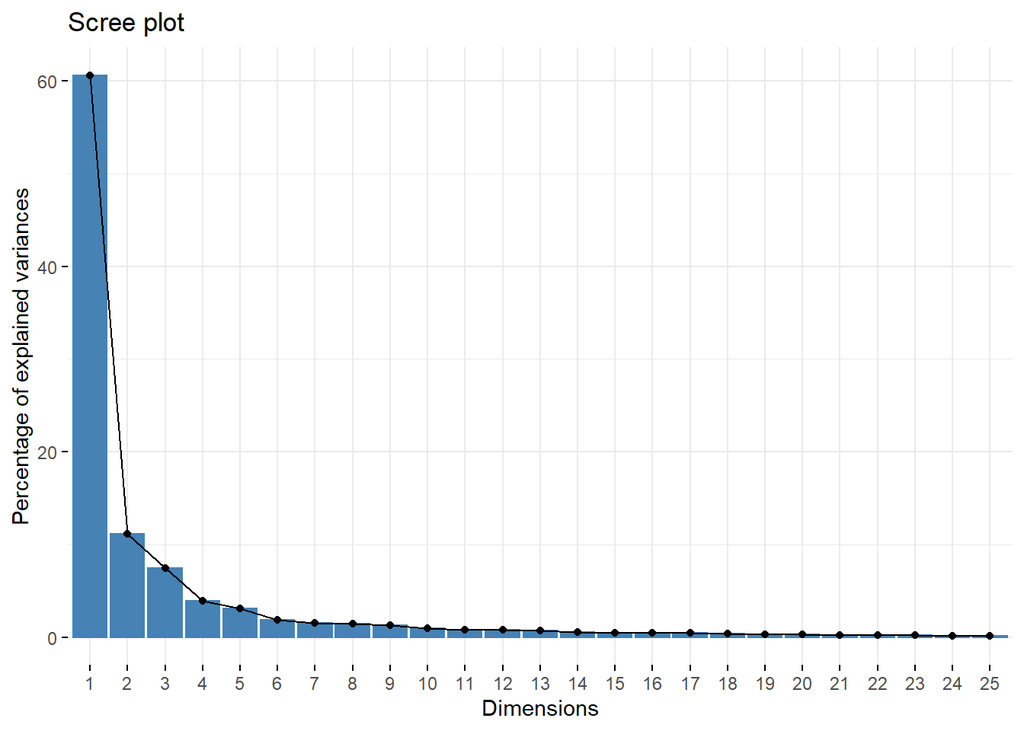

```r
### visualize the fraction of the variance explained per PC with a scree plot
factoextra::fviz_screeplot(ready_pca, addlabels = FALSE, ncp = 25)
```

How can I change the dimension to include all 52?

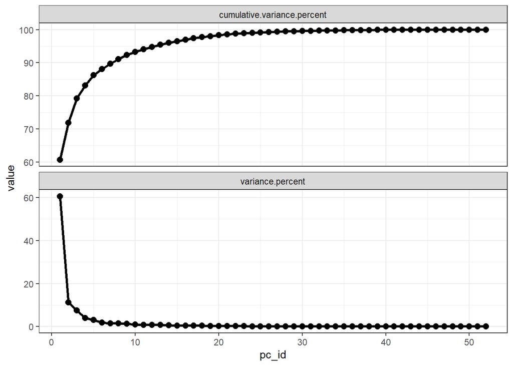

```r
### cumultive or total variance explained
factoextra::get_eigenvalue(ready_pca) %>%
  select(ends_with("percent")) %>%
  tibble::rownames_to_column() %>%
  tibble::as_tibble() %>%
  mutate(pc_id = as.numeric(stringr::str_extract(rowname, "\\d+"))) %>%
  pivot_longer(!c("rowname", "pc_id")) %>%
  ggplot(mapping = aes(x = pc_id, y = value)) +
  geom_point(size = 2.5) +
  geom_line(mapping = aes(group = name),
            size = 1.1) +
  facet_wrap(~name, scales = "free_y", ncol = 1) +
  theme_bw()
```

### which of the original variables relates to the PCS?

### the loadings matrix tells us that!

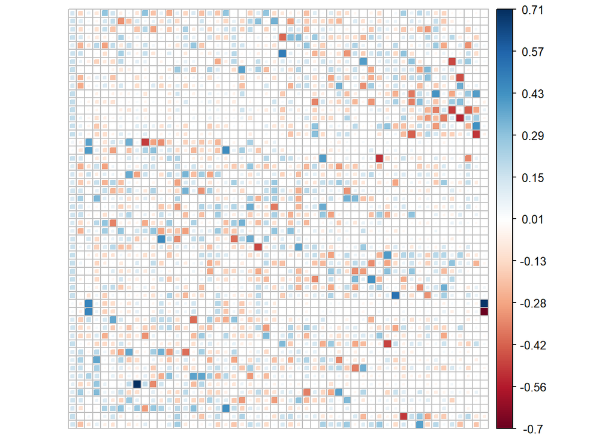

```r
corrplot::corrplot(ready_pca$rotation, is.corr = FALSE, method = "square", tl.cex=0.85, tl.pos = 'n')
```

Hard to identify groups/variables in the above corr plot (mix of positive and negative)

```r
## check which variables have negative loadings to PC1
ready_pca$rotation[, 1]
```

```
##            GMD-Caudate-L            GMD-Caudate-R   GMD-Frontal_Inf_Oper-L
##               0.13171066               0.14972445               0.14458444
##   GMD-Frontal_Inf_Oper-R  GMD-Frontal_Inf_Orb_2-L  GMD-Frontal_Inf_Orb_2-R
##               0.15998118               0.09449789               0.15248582
##    GMD-Frontal_Inf_Tri-L    GMD-Frontal_Inf_Tri-R    GMD-Frontal_Med_Orb-L
##               0.16062102               0.16994027               0.13312179
##    GMD-Frontal_Med_Orb-R      GMD-Frontal_Mid_2-L      GMD-Frontal_Mid_2-R
##               0.12461341               0.17501185               0.17186467
##      GMD-Frontal_Sup_2-L      GMD-Frontal_Sup_2-R GMD-Frontal_Sup_Medial-L
##               0.17493008               0.17161174               0.16139989
## GMD-Frontal_Sup_Medial-R           GMD-Fusiform-L           GMD-Fusiform-R
##               0.16483094               0.04197174               0.02488637
##             GMD-Heschl-L             GMD-Heschl-R             GMD-Insula-L
##               0.15992174               0.09748968               0.13225694
##             GMD-Insula-R             GMD-OFCant-L             GMD-OFCant-R
##               0.12041484               0.13864132               0.11234627
##           GMD-Pallidum-L           GMD-Pallidum-R    GMD-ParaHippocampal-L
##               0.15422939               0.14932763               0.11652339
##    GMD-ParaHippocampal-R       GMD-Parietal_Inf-L       GMD-Parietal_Inf-R
##               0.09149472               0.14555775               0.15202607
##        GMD-Postcentral-L        GMD-Postcentral-R         GMD-Precentral-L
##               0.16678229               0.16515993               0.16790516
##         GMD-Precentral-R            GMD-Putamen-L            GMD-Putamen-R
##               0.16692444               0.16388325               0.16275248
##             GMD-Rectus-L             GMD-Rectus-R      GMD-Rolandic_Oper-L
##               0.03052213               0.03130340               0.11703722
##      GMD-Rolandic_Oper-R      GMD-SupraMarginal-L      GMD-SupraMarginal-R
##               0.14482726               0.13074204               0.16454451
##       GMD-Temporal_Inf-L       GMD-Temporal_Inf-R       GMD-Temporal_Mid-L
##               0.10730261               0.09540787               0.14491803
##       GMD-Temporal_Mid-R  GMD-Temporal_Pole_Mid-L  GMD-Temporal_Pole_Mid-R
##               0.11934089               0.08391531               0.10372873
##  GMD-Temporal_Pole_Sup-L  GMD-Temporal_Pole_Sup-R       GMD-Temporal_Sup-L
##               0.14937577               0.12871792               0.17049889
##       GMD-Temporal_Sup-R
##               0.14035374
```

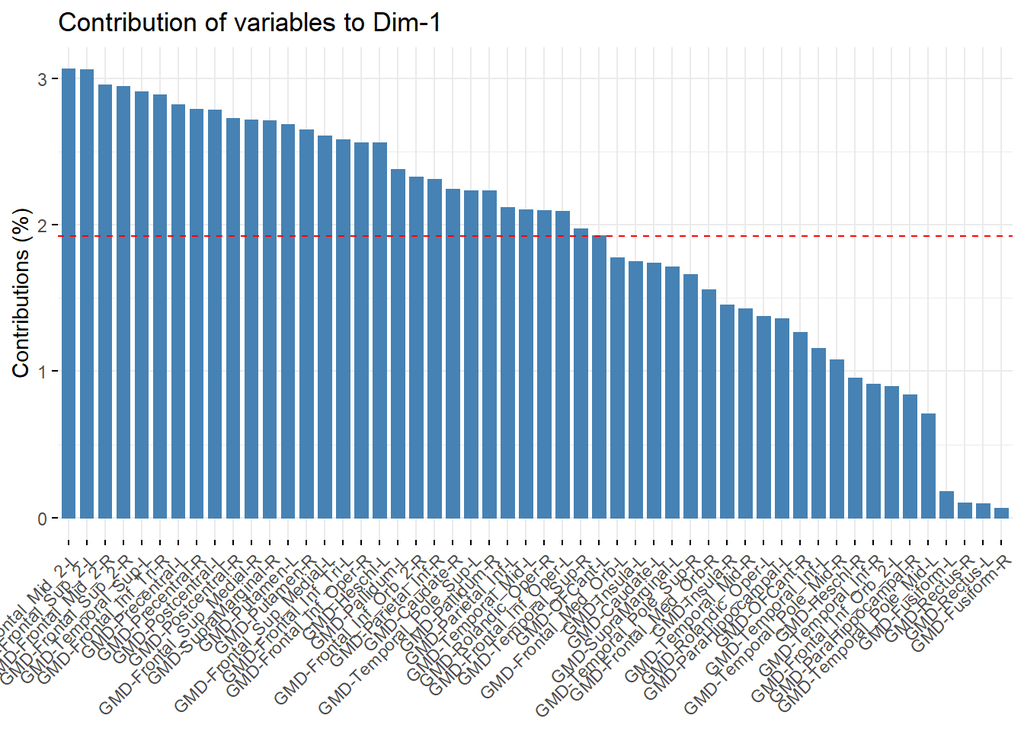

```r
### squaring the loadings gives us the CONTRIBUTION of the variables

### to the PC regardless of direction

### can visualize the as a barchart
factoextra::fviz_contrib(ready_pca, choice = 'var', axes = 1, tl.pos = 'n')
```

Can I remove the labels to visualize regions that correspond to higher contributions to PC regardless of direction

```r
### check
sort(100 * (ready_pca$rotation[, 1]^2 / sum(ready_pca$rotation[, 1]^2) ), decreasing = TRUE)
```

```
##      GMD-Frontal_Mid_2-L      GMD-Frontal_Sup_2-L      GMD-Frontal_Mid_2-R
##               3.06291473               3.06005340               2.95374650
##      GMD-Frontal_Sup_2-R       GMD-Temporal_Sup-L    GMD-Frontal_Inf_Tri-R
##               2.94505897               2.90698726               2.88796963
##         GMD-Precentral-L         GMD-Precentral-R        GMD-Postcentral-L
##               2.81921426               2.78637698               2.78163329
##        GMD-Postcentral-R GMD-Frontal_Sup_Medial-R      GMD-SupraMarginal-R
##               2.72778032               2.71692395               2.70748956
##            GMD-Putamen-L            GMD-Putamen-R GMD-Frontal_Sup_Medial-L
##               2.68577188               2.64883705               2.60499236
##    GMD-Frontal_Inf_Tri-L   GMD-Frontal_Inf_Oper-R             GMD-Heschl-L
##               2.57991118               2.55939785               2.55749637
##           GMD-Pallidum-L  GMD-Frontal_Inf_Orb_2-R       GMD-Parietal_Inf-R
##               2.37867037               2.32519265               2.31119250
##            GMD-Caudate-R  GMD-Temporal_Pole_Sup-L           GMD-Pallidum-R
##               2.24174118               2.23131217               2.22987405
##       GMD-Parietal_Inf-L       GMD-Temporal_Mid-L      GMD-Rolandic_Oper-R
##               2.11870572               2.10012356               2.09749352
##   GMD-Frontal_Inf_Oper-L       GMD-Temporal_Sup-R             GMD-OFCant-L
##               2.09046604               1.96991728               1.92214154
##    GMD-Frontal_Med_Orb-L             GMD-Insula-L            GMD-Caudate-L
##               1.77214113               1.74918984               1.73476969
##      GMD-SupraMarginal-L  GMD-Temporal_Pole_Sup-R    GMD-Frontal_Med_Orb-R
##               1.70934808               1.65683018               1.55285022
##             GMD-Insula-R       GMD-Temporal_Mid-R      GMD-Rolandic_Oper-L
##               1.44997329               1.42422471               1.36977105
##    GMD-ParaHippocampal-L             GMD-OFCant-R       GMD-Temporal_Inf-L
##               1.35777000               1.26216850               1.15138497
##  GMD-Temporal_Pole_Mid-R             GMD-Heschl-R       GMD-Temporal_Inf-R
##               1.07596496               0.95042371               0.91026608
##  GMD-Frontal_Inf_Orb_2-L    GMD-ParaHippocampal-R  GMD-Temporal_Pole_Mid-L
##               0.89298505               0.83712831               0.70417788
##           GMD-Fusiform-L             GMD-Rectus-R             GMD-Rectus-L
##               0.17616271               0.09799029               0.09316004
##           GMD-Fusiform-R
##               0.06193315
```